# Week 5 Analysis - Dimensionality reduction techniques

Juho Lähteenmaa

29 November 2018

# Analysis, IODS week 5

Here are the packages used in this session:

```r
# REMOVE ALL OBJECTS
rm(list=ls())

library(GGally)
library(ggplot2)
library(dplyr)
library(corrplot)
library(tidyr)
library(FactoMineR)
```

# Human data

## Import data

Let’s import data and have a small lookup in it.

```r
human <- read.csv("C:/Users/juhol/OneDrive/Documents/GitHub/IODS-project/data/human.csv", sep  =",", header = T, row.names = 1)


# look at the (column) names of human
names(human)
```

```
## [1] "life_exp"                 "exp_years_education"
## [3] "gni"                      "maternal_mortality_ratio"
## [5] "adolescent_birth_rate"    "female_parliament"
## [7] "sec_edu_ratio"            "labour_rate_ratio"
```

```r
# look at the structure of human
str(human)
```

```
## 'data.frame':    155 obs. of  8 variables:
##  $ life_exp                : num  81.6 82.4 83 80.2 81.6 80.9 80.9 79.1 82 81.8 ...
##  $ exp_years_education     : num  17.5 20.2 15.8 18.7 17.9 16.5 18.6 16.5 15.9 19.2 ...
##  $ gni                     : int  64992 42261 56431 44025 45435 43919 39568 52947 42155 32689 ...
##  $ maternal_mortality_ratio: int  4 6 6 5 6 7 9 28 11 8 ...
##  $ adolescent_birth_rate   : num  7.8 12.1 1.9 5.1 6.2 3.8 8.2 31 14.5 25.3 ...
##  $ female_parliament       : num  39.6 30.5 28.5 38 36.9 36.9 19.9 19.4 28.2 31.4 ...
##  $ sec_edu_ratio           : num  1.007 0.997 0.983 0.989 0.969 ...
##  $ labour_rate_ratio       : num  0.891 0.819 0.825 0.884 0.829 ...
```

```r
# print out summaries of the variables
summary(human)
```

```
##     life_exp     exp_years_education      gni
##  Min.   :49.00   Min.   : 5.40       Min.   :   581
##  1st Qu.:66.30   1st Qu.:11.25       1st Qu.:  4198
##  Median :74.20   Median :13.50       Median : 12040
##  Mean   :71.65   Mean   :13.18       Mean   : 17628
##  3rd Qu.:77.25   3rd Qu.:15.20       3rd Qu.: 24512
##  Max.   :83.50   Max.   :20.20       Max.   :123124
##  maternal_mortality_ratio adolescent_birth_rate female_parliament
##  Min.   :   1.0           Min.   :  0.60        Min.   : 0.00
##  1st Qu.:  11.5           1st Qu.: 12.65        1st Qu.:12.40
##  Median :  49.0           Median : 33.60        Median :19.30
##  Mean   : 149.1           Mean   : 47.16        Mean   :20.91
##  3rd Qu.: 190.0           3rd Qu.: 71.95        3rd Qu.:27.95
##  Max.   :1100.0           Max.   :204.80        Max.   :57.50
##  sec_edu_ratio    labour_rate_ratio
##  Min.   :0.1717   Min.   :0.1857
##  1st Qu.:0.7264   1st Qu.:0.5984
##  Median :0.9375   Median :0.7535
##  Mean   :0.8529   Mean   :0.7074
##  3rd Qu.:0.9968   3rd Qu.:0.8535
##  Max.   :1.4967   Max.   :1.0380
```

In our first part of analysis we are taking a brief look in OECD data from [HUMAN DEVELOPMENT REPORT 2015](http://hdr.undp.org/sites/default/files/hdr2015_technical_notes.pdf). In this section we are using subset from original data including variables *Life expectancy at birth*, *Expected years of schooling*, *GNI per capita*, *Maternal mortality ratio*, *Adolescent birth rate*, *Female’s share of parliamentary seats*, *Female and male ratio of at least secondary education* and *Female and male ratio labour force participation rates*. In dataset we have 155 observations which are representing countries.

All variables are including only numerical values. From summary we can see that all variables are variating relatively highly. Let’s have visual perspective in data.

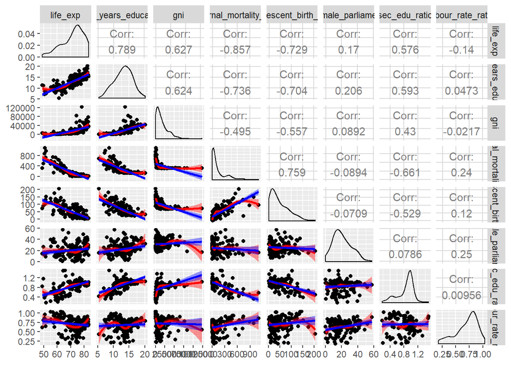

```r
# visualize the 'human' variables


my_fn <- function(data, mapping, ...){
  p <- ggplot(data = data, mapping = mapping) +
    geom_point() +
    geom_smooth(method=loess, fill="red", color="red", ...) +
    geom_smooth(method=lm, fill="blue", color="blue", ...)
  p
}



ggpairs(human, lower = list(continuous = my_fn))
```

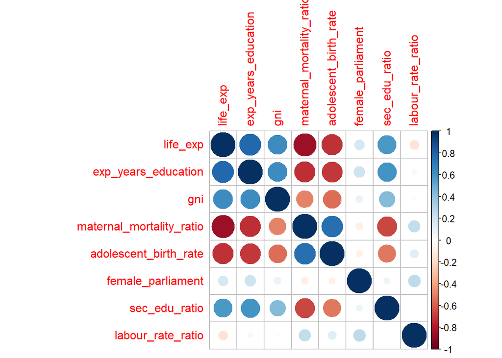

```r
# compute the correlation matrix and visualize it with corrplot
cor(human) %>% corrplot
```

## PCA not standardized for human data

Next we are using *principal components analysis* (PCA) for human data. At first, we are analysing not standardized human data and after that we are comparing the results with standardized data.PCA is popular approach to reduce the dimensions in data. The main idea in PCA technique is to find the principal components, meaning the directions where observations have most variation. The first principal component is the direction where data is variating the most, the second principal component is the direction where data is variating the second most and etc.

```r
pca_human_not_std <- prcomp(human)

sum_pca_human_not_std <- summary(pca_human_not_std)

# rounded percetanges of variance captured by each PC
pca_pr_not_std <- round(100*sum_pca_human_not_std$importance[2, ], digits = 3)

# print out the percentages of variance
pca_pr_not_std
```

```
##   PC1   PC2   PC3   PC4   PC5   PC6   PC7   PC8
## 99.99  0.01  0.00  0.00  0.00  0.00  0.00  0.00
```

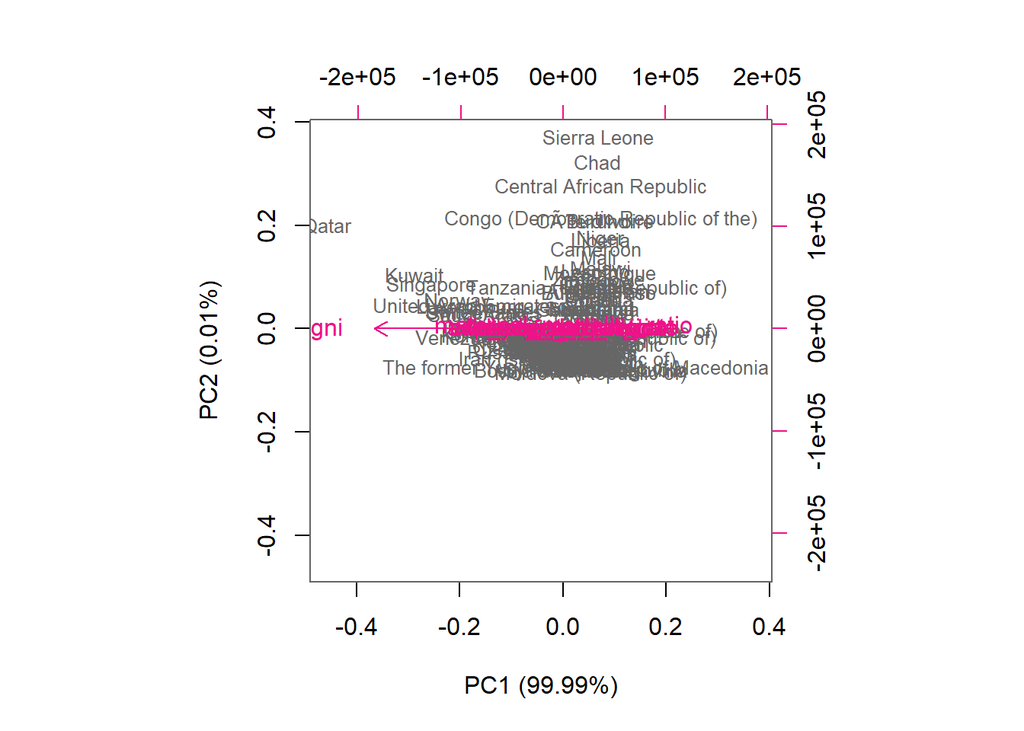

```r
# create object pc_lab to be used as axis labels
pc_lab_not_std <- paste0(names(pca_pr_not_std), " (", pca_pr_not_std, "%)")

# draw a biplot
biplot(pca_human_not_std, cex = c(0.8, 1), col = c("grey40", "deeppink2"), xlab = pc_lab_not_std[1], ylab = pc_lab_not_std[2])
```

The first principal component is capturing nearly all the variance (99.99%). The *GNI* variable is nearly only component spanning the PC1. This comes from the fact that *GNI* is variating between 581 -123124 where other variables variation is dozens of times smaller. That is why we have to standardize our data before using PCA.

## PCA standardized for human data

```r
human_std <- scale(human)

pca_human <- prcomp(human_std)

sum_pca_human <- summary(pca_human)

# rounded percetanges of variance captured by each PC
pca_pr <- round(100*sum_pca_human$importance[2, ], digits = 3)

# print out the percentages of variance
pca_pr
```

```
##    PC1    PC2    PC3    PC4    PC5    PC6    PC7    PC8
## 53.605 16.237  9.571  7.583  5.477  3.595  2.634  1.298
```

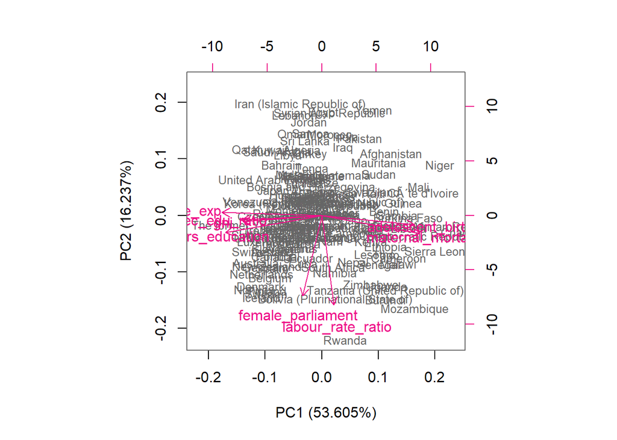

```r
# create object pc_lab to be used as axis labels
pc_lab <- paste0(names(pca_pr), " (", pca_pr, "%)")

# draw a biplot
biplot(pca_human, cex = c(0.8, 1), col = c("grey40", "deeppink2"), xlab = pc_lab[1], ylab = pc_lab[2])
```

Now principal components are capturing reasonable amount of variation. The PC1 is capturing 53.6 % of variation, PC2 16.2% and cumulatively the first two PCs are capturing 69.8 % of variation. Interpretation of the graph above is that x-axis is representing the dimension spanned by PC1 and y-axis is correspondly representing the dimension spanned by PC2. Variance of our variables can be represented as linear combination of the principal components. For example, *life expectancy’s* coefficient in direction PC1 is -0.44 when *maternal_mortality_ratio* has opposite direction in dimension PC1 with coefficient 0.44. In two first principal components spanned space *life expectancy* and *labour rate ratio* are nearly orthogonal meaning that variance of the first is orthogonal related to to others variance (correlation between these two variables is -0.14). In space spanned with fist eight principal components cordinate for *life expectancy* is $[-0.44372240, 0.02530473, -0.10991305, 0.05834819, -0.1628935, 0.42242796, -0.43406432, -0.62737008]$.

In our bixplot horizontal dimension (PC1) can bee seen as representation of the wealthy of the country and vertical direction (PC2) as equility variance. In the South-West corner of the bixplot we can find Northern Countries and from the really opposite corner countries such as Yemen and Afghanistan.

For making the analyse it is necessary to scale the data. PCA is based only on the variance of the data and normally we are not interested in the differences of variance relating the scale.

## Tea time

Let’s import the *Tea* data from the package Factominer.

```r
tea <- read.table("http://factominer.free.fr/book/tea.csv",header=TRUE,sep=";")

colnames(tea)
```

```
##  [1] "breakfast"         "afternoon.tea"     "evening"
##  [4] "after.lunch"       "after.dinner"      "anytime"
##  [7] "home"              "work"              "tearoom"
## [10] "friends"           "restaurant"        "pub"
## [13] "variety"           "how"               "sugar"
## [16] "format"            "place.of.purchase" "type"
## [19] "sex"               "profession"        "sport"
## [22] "age"               "age_Q"             "frequency"
## [25] "exotic"            "spirituality"      "good.for.health"
## [28] "diuretic"          "friendliness"      "iron.absorption"
## [31] "feminine"          "refined"           "slimming"
## [34] "stimulant"         "relaxant"          "no.effect.health"
```

```r
str(tea)
```

```
## 'data.frame':    300 obs. of  36 variables:
##  $ breakfast        : Factor w/ 2 levels "breakfast","not.breakfast": 1 1 2 2 1 2 1 2 1 1 ...
##  $ afternoon.tea    : Factor w/ 2 levels "afternoon.tea",..: 2 2 1 2 2 2 1 1 1 2 ...
##  $ evening          : Factor w/ 2 levels "evening","not.evening": 2 2 1 2 1 2 2 1 2 1 ...
##  $ after.lunch      : Factor w/ 2 levels "after.lunch",..: 2 2 2 2 2 2 2 2 2 2 ...
##  $ after.dinner     : Factor w/ 2 levels "after.dinner",..: 2 2 1 1 2 1 2 2 2 2 ...
##  $ anytime          : Factor w/ 2 levels "anytime","not.anytime": 2 2 2 2 1 2 2 2 2 2 ...
##  $ home             : Factor w/ 2 levels "home","not.home": 1 1 1 1 1 1 1 1 1 1 ...
##  $ work             : Factor w/ 2 levels "not.work","work": 1 1 2 1 1 1 1 1 1 1 ...
##  $ tearoom          : Factor w/ 2 levels "not.tearoom",..: 1 1 1 1 1 1 1 1 1 2 ...
##  $ friends          : Factor w/ 2 levels "friends","not.friends": 2 2 1 2 2 2 1 2 2 2 ...
##  $ restaurant       : Factor w/ 2 levels "not.restaurant",..: 1 1 2 1 1 1 1 1 1 1 ...
##  $ pub              : Factor w/ 2 levels "not.pub","pub": 1 1 1 1 1 1 1 1 1 1 ...
##  $ variety          : Factor w/ 3 levels "black","flavoured",..: 1 1 2 2 2 2 2 1 2 1 ...
##  $ how              : Factor w/ 4 levels "lemon","milk",..: 3 2 3 3 3 3 3 2 2 3 ...
```

[output cut: 22 more lines]

```r
summary(tea)
```

```
##          breakfast           afternoon.tea        evening
##  breakfast    :144   afternoon.tea  :169   evening    :103
##  not.breakfast:156   Not.afternoon.t:131   not.evening:197
##
##
##
##
##
##           after.lunch            after.dinner        anytime
##  after.lunch    : 44   after.dinner    : 21   anytime    :103
##  not.after.lunch:256   not.after.dinner:279   not.anytime:197
##
##
##
##
##
##        home           work            tearoom           friends
##  home    :291   not.work:213   not.tearoom:242   friends    :196
##  not.home:  9   work    : 87   tearoom    : 58   not.friends:104
##
##
##
##
##
##           restaurant       pub           variety               how
##  not.restaurant:221   not.pub:237   black    : 74   lemon        : 33
##  restaurant    : 79   pub    : 63   flavoured:193   milk         : 63
##                                     green    : 33   nothing.added:195
##                                                     other        :  9
##
##
##
##        sugar              format                  place.of.purchase
##  not.sugar:155   loose       : 36   specialist.shop        : 30
##  sugar    :145   sachet      :170   supermarket            :192
##                  sachet+loose: 94   supermarket+specialist.: 78
##
##
##
##
```

[output cut: 33 more lines]

```
##  not.refined: 85   not.slimming:255   not.stimulant:184
##  refined    :215   slimming    : 45   stimulant    :116
##
##
##
##
##
##          relaxant                    no.effect.health
##  not.relaxant:113   no.effect.health         : 66
##  relaxant    :187   not.without.effect.health:234
##
##
##
##
##
```

In *Tea* data most of the variables are in factor format. Data is containing 36 variables and 300 observations. Let’s have a visual overlook in data.

```r
# Splitting the plot

colnames(tea)
```

```
##  [1] "breakfast"         "afternoon.tea"     "evening"
##  [4] "after.lunch"       "after.dinner"      "anytime"
##  [7] "home"              "work"              "tearoom"
## [10] "friends"           "restaurant"        "pub"
## [13] "variety"           "how"               "sugar"
## [16] "format"            "place.of.purchase" "type"
## [19] "sex"               "profession"        "sport"
## [22] "age"               "age_Q"             "frequency"
## [25] "exotic"            "spirituality"      "good.for.health"
## [28] "diuretic"          "friendliness"      "iron.absorption"
## [31] "feminine"          "refined"           "slimming"
## [34] "stimulant"         "relaxant"          "no.effect.health"
```

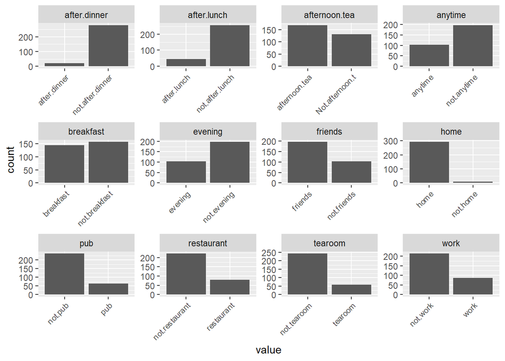

```r
tea_subset_1 <- dplyr::select(tea, breakfast:pub)

tea_subset_2 <- dplyr::select(tea, variety:frequency) %>% select(-age)

tea_subset_3 <- dplyr::select(tea, exotic:no.effect.health)

# visualize the dataset

gather(tea_subset_1) %>% ggplot(aes(value)) + facet_wrap("key", scales = "free") + geom_bar() + theme(axis.text.x = element_text(angle = 45, hjust = 1, size = 8))
```

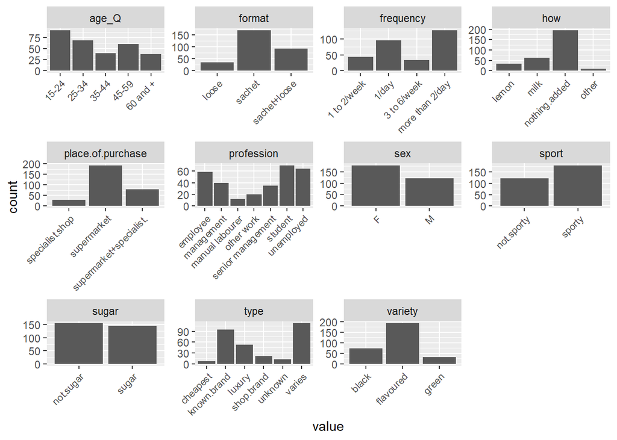

```r
gather(tea_subset_2) %>% ggplot(aes(value)) + facet_wrap("key", scales = "free") + geom_bar() + theme(axis.text.x = element_text(angle = 45, hjust = 1, size = 8))
```

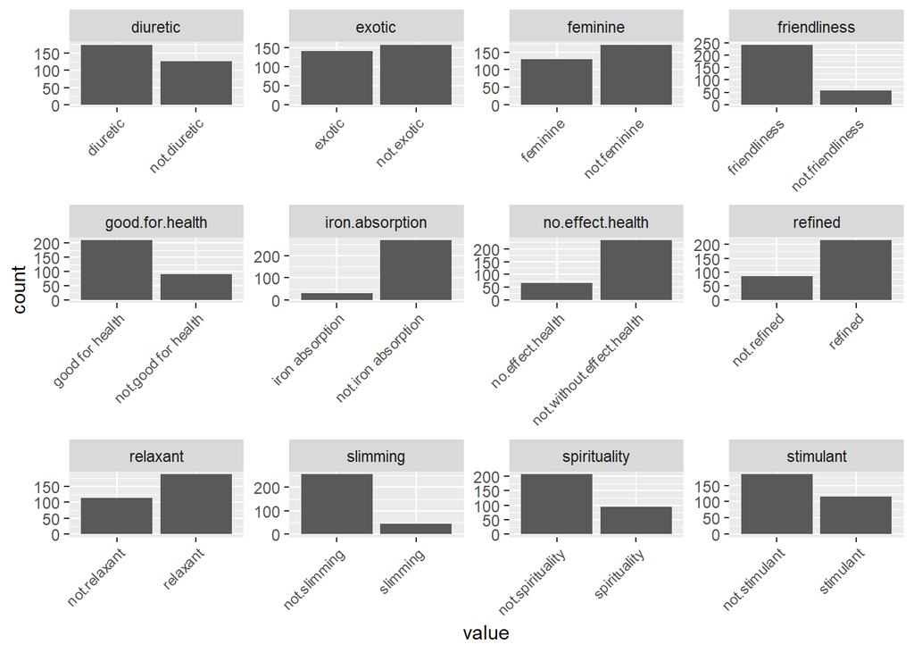

```r
gather(tea_subset_3) %>% ggplot(aes(value)) + facet_wrap("key", scales = "free") + geom_bar() + theme(axis.text.x = element_text(angle = 45, hjust = 1, size = 8))
```

The last 12 variables are all categorical variables in “yes - now” dimension. They all are represnting reasons to consume tea. In this part of analysis we are interested in these variables.

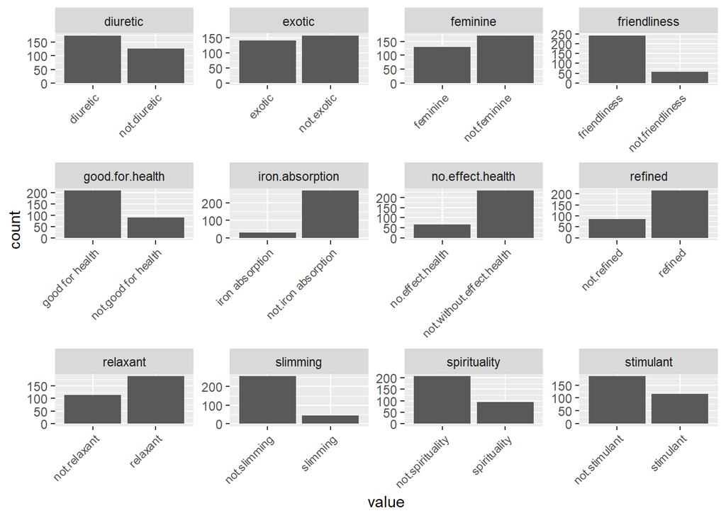

```r
# Lets select subset of data. Why people are drinking tea?

tea_time <- dplyr::select(tea, exotic, spirituality, good.for.health, diuretic, friendliness, iron.absorption, feminine, refined, slimming, stimulant, relaxant, no.effect.health)

gather(tea_time) %>% ggplot(aes(value)) + facet_wrap("key", scales = "free") + geom_bar() + theme(axis.text.x = element_text(angle = 45, hjust = 1, size = 8))
```

For categorical varibles there is technique which is closely corresponding the PCA, *Multiple Correspondence Analysis* (*MCA*). More about *MCA* can be read from [here](https://en.wikipedia.org/wiki/Multiple_correspondence_analysis#As_an_extension_of_correspondences_analysis).

```r
# multiple correspondence analysis
mca <- MCA(tea_time, graph = FALSE)

# summary of the model
summary(mca)
```

```
##
## Call:
## MCA(X = tea_time, graph = FALSE)
##
##
## Eigenvalues
##                        Dim.1   Dim.2   Dim.3   Dim.4   Dim.5   Dim.6
## Variance               0.141   0.121   0.104   0.098   0.096   0.081
## % of var.             14.140  12.066  10.407   9.788   9.606   8.136
## Cumulative % of var.  14.140  26.207  36.613  46.401  56.007  64.143
##                        Dim.7   Dim.8   Dim.9  Dim.10  Dim.11  Dim.12
## Variance               0.073   0.066   0.063   0.059   0.052   0.045
## % of var.              7.271   6.626   6.280   5.905   5.237   4.537
## Cumulative % of var.  71.414  78.040  84.321  90.226  95.463 100.000
##
## Individuals (the 10 first)
##                        Dim.1    ctr   cos2    Dim.2    ctr   cos2    Dim.3
## 1                   | -0.691  1.124  0.425 | -0.345  0.329  0.106 | -0.384
## 2                   | -0.307  0.222  0.081 |  0.155  0.066  0.020 | -0.565
## 3                   | -0.215  0.109  0.071 | -0.518  0.742  0.411 | -0.255
## 4                   | -0.123  0.036  0.015 | -0.284  0.223  0.079 |  0.539
## 5                   | -0.190  0.085  0.037 | -0.038  0.004  0.001 |  0.321
## 6                   | -0.608  0.872  0.357 | -0.578  0.922  0.322 | -0.036
## 7                   | -0.608  0.872  0.357 | -0.578  0.922  0.322 | -0.036
## 8                   |  0.048  0.005  0.004 | -0.448  0.554  0.347 |  0.161
## 9                   | -0.612  0.883  0.368 | -0.205  0.116  0.041 |  0.308
## 10                  | -0.215  0.109  0.071 | -0.518  0.742  0.411 | -0.255
##                        ctr   cos2
## 1                    0.473  0.131 |
## 2                    1.023  0.274 |
## 3                    0.209  0.100 |
## 4                    0.931  0.285 |
## 5                    0.329  0.105 |
## 6                    0.004  0.001 |
## 7                    0.004  0.001 |
## 8                    0.083  0.045 |
## 9                    0.303  0.093 |
## 10                   0.209  0.100 |
##
## Categories (the 10 first)
```

[output cut: 20 more lines]

```
## friendliness        -0.287 | -0.014  0.012  0.001 -0.485 |
## not.friendliness     0.287 |  0.057  0.051  0.001  0.485 |
##
## Categorical variables (eta2)
##                       Dim.1 Dim.2 Dim.3
## exotic              | 0.041 0.140 0.163 |
## spirituality        | 0.122 0.002 0.122 |
## good.for.health     | 0.230 0.285 0.093 |
## diuretic            | 0.228 0.020 0.147 |
## friendliness        | 0.102 0.000 0.001 |
## iron.absorption     | 0.068 0.008 0.011 |
## feminine            | 0.310 0.009 0.007 |
## refined             | 0.215 0.030 0.090 |
## slimming            | 0.275 0.055 0.003 |
## stimulant           | 0.030 0.258 0.127 |
```

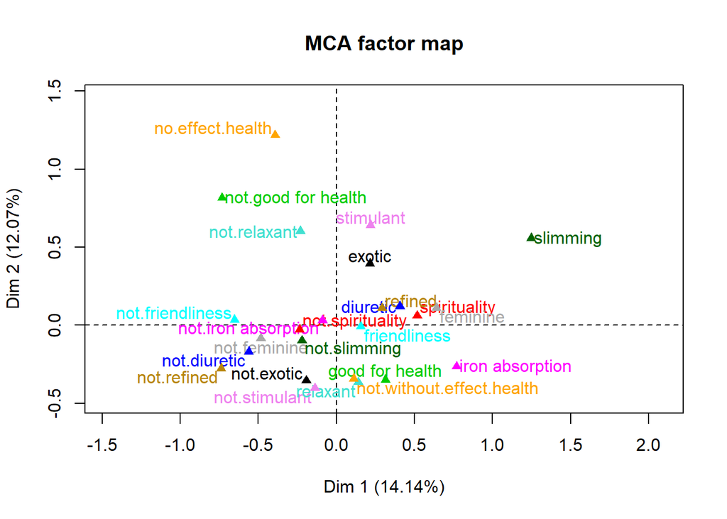

```r
# visualize MCA
plot(mca, invisible=c("ind"), habillage = "quali")
```

As in PCA, dimensions are ordered by the variance. Dim 1 is capturing 14.1 % of the overall variance. Cumulatively first two variables are responding 26.2 % of the variance, meaning that major part of the data’s overall variance is captured by other dimensions.

From bixplot above we can see that most of the categorical varibles values are quite near by the origo in our 2D space. This means that two dimensional MCA model does not explain major part of the variaty in our *tea* data. Still, there are some values in our data making clusters, for example group of values *no effect on health*, *not good for health* and *not relaxant* can be ditinguished (interpretation could be “the cluster of pessimists”). Dim 1 could be seen as “effect of the tea” dimension where values in left are not indentifying any effect of the and in the right values are more devoted on positive effect of tea.